# Participation 6

1. Scatter plot of the entire diamond sample, graphed with carat on x and price on the y axis. The color each of the points is based on their clarity.

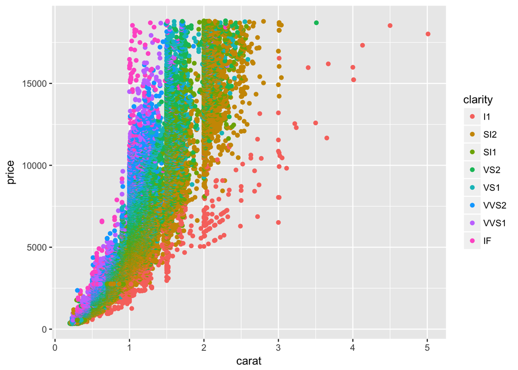

2. Scatter plot of the diamond sample, graphed with carat on the x axis and cut on the y axis. The size of the dots are based on the price of the diamond.

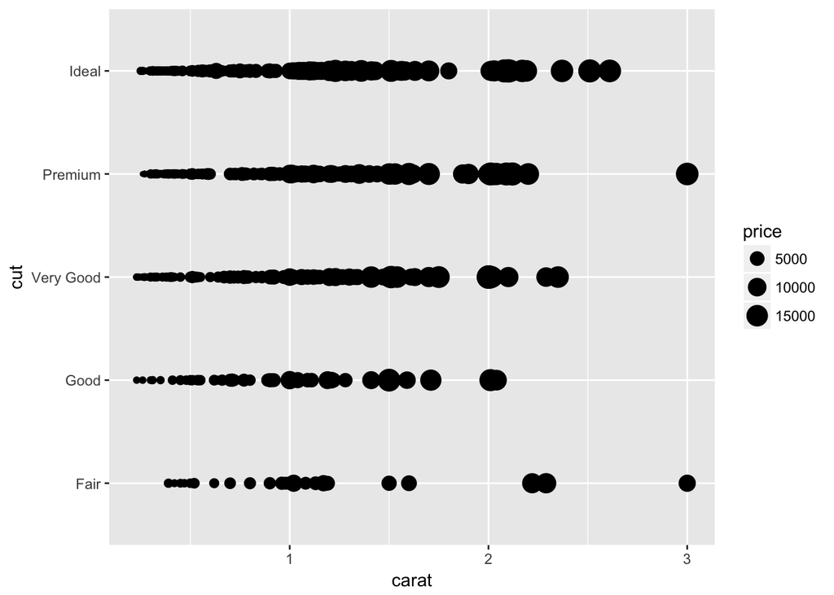

3. Smooth plot of the diamond sample, graphed with carat on the x axis, and price on the y axis. The color is based on the cut of the diamond.

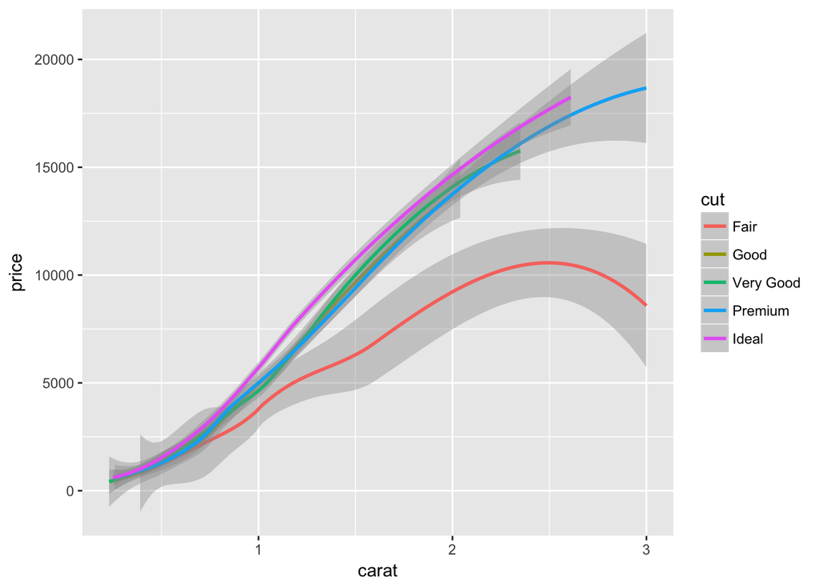

4. Bar plot of the diamond sample, graphed with cut on the x axis, and frequency on the y axis.

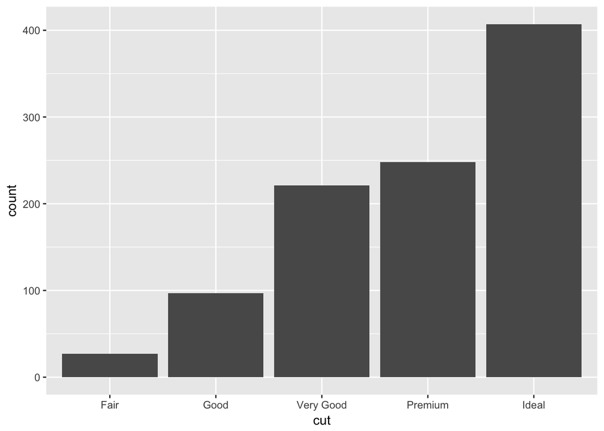

5. Histogram of the diamond sample, graphed with price on the x axis, and frequency on the y axis. The color is based on the clarity of the diamond.

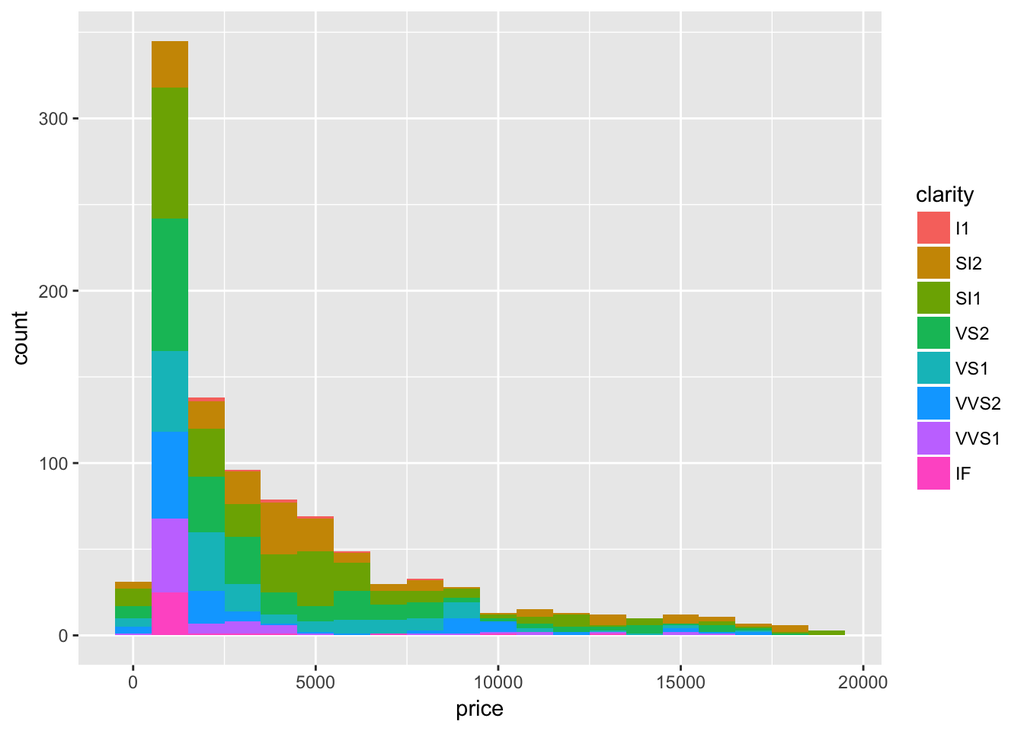

6. Smooth and scatter plot of the diamond sample, graphed with carat on the x axis, and price on the y axis. The two colors differentiate the types of plots.

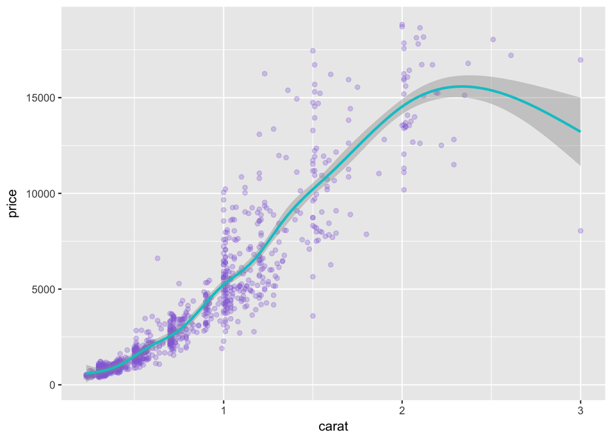